# Risk Factor Analysis

## Outcome Variable

**Outcome Variable:** ever_stunted

## Predictor Variables

**Intervention Variable:** perdiar6

**Adjustment Set:**

- arm
- W_mage
- meducyrs
- W_mhtcm
- W_mwtkg
- W_mbmi
- W_birthwt
- W_birthlen
- W_nrooms
- month
- brthmon
- impfloor
- impsan
- safeh20
- delta_W_mage
- delta_meducyrs
- delta_W_mhtcm
- delta_W_mwtkg
- delta_W_mbmi
- delta_W_birthwt
- delta_W_birthlen
- delta_W_nrooms
- delta_month
- delta_brthmon
- delta_impfloor
- delta_impsan
- delta_safeh20

## Stratifying Variables

The analysis was stratified on these variable(s):

- agecat
- studyid
- country

## Data Summary

| agecat | studyid | country | perdiar6 | ever_stunted | n_cell | n |
| --- | --- | --- | --- | --- | --- | --- |
| 0-24 months (no birth st.) | ki0047075b-MAL-ED | BANGLADESH | 0% | 0 | 36 | 217 |
| 0-24 months (no birth st.) | ki0047075b-MAL-ED | BANGLADESH | 0% | 1 | 36 | 217 |
| 0-24 months (no birth st.) | ki0047075b-MAL-ED | BANGLADESH | (0%, 5%] | 0 | 41 | 217 |
| 0-24 months (no birth st.) | ki0047075b-MAL-ED | BANGLADESH | (0%, 5%] | 1 | 44 | 217 |
| 0-24 months (no birth st.) | ki0047075b-MAL-ED | BANGLADESH | >5% | 0 | 27 | 217 |
| 0-24 months (no birth st.) | ki0047075b-MAL-ED | BANGLADESH | >5% | 1 | 33 | 217 |
| 0-24 months (no birth st.) | ki0047075b-MAL-ED | BRAZIL | 0% | 0 | 165 | 208 |
| 0-24 months (no birth st.) | ki0047075b-MAL-ED | BRAZIL | 0% | 1 | 27 | 208 |
| 0-24 months (no birth st.) | ki0047075b-MAL-ED | BRAZIL | (0%, 5%] | 0 | 12 | 208 |
| 0-24 months (no birth st.) | ki0047075b-MAL-ED | BRAZIL | (0%, 5%] | 1 | 2 | 208 |
| 0-24 months (no birth st.) | ki0047075b-MAL-ED | BRAZIL | >5% | 0 | 2 | 208 |
| 0-24 months (no birth st.) | ki0047075b-MAL-ED | BRAZIL | >5% | 1 | 0 | 208 |
| 0-24 months (no birth st.) | ki0047075b-MAL-ED | INDIA | 0% | 0 | 24 | 209 |
| 0-24 months (no birth st.) | ki0047075b-MAL-ED | INDIA | 0% | 1 | 25 | 209 |
| 0-24 months (no birth st.) | ki0047075b-MAL-ED | INDIA | (0%, 5%] | 0 | 54 | 209 |
| 0-24 months (no birth st.) | ki0047075b-MAL-ED | INDIA | (0%, 5%] | 1 | 52 | 209 |
| 0-24 months (no birth st.) | ki0047075b-MAL-ED | INDIA | >5% | 0 | 23 | 209 |
| 0-24 months (no birth st.) | ki0047075b-MAL-ED | INDIA | >5% | 1 | 31 | 209 |
| 0-24 months (no birth st.) | ki0047075b-MAL-ED | NEPAL | 0% | 0 | 54 | 212 |
| 0-24 months (no birth st.) | ki0047075b-MAL-ED | NEPAL | 0% | 1 | 20 | 212 |
| 0-24 months (no birth st.) | ki0047075b-MAL-ED | NEPAL | (0%, 5%] | 0 | 54 | 212 |
| 0-24 months (no birth st.) | ki0047075b-MAL-ED | NEPAL | (0%, 5%] | 1 | 14 | 212 |
| 0-24 months (no birth st.) | ki0047075b-MAL-ED | NEPAL | >5% | 0 | 49 | 212 |
| 0-24 months (no birth st.) | ki0047075b-MAL-ED | NEPAL | >5% | 1 | 21 | 212 |
| 0-24 months (no birth st.) | ki0047075b-MAL-ED | PERU | 0% | 0 | 37 | 266 |
| 0-24 months (no birth st.) | ki0047075b-MAL-ED | PERU | 0% | 1 | 40 | 266 |
| 0-24 months (no birth st.) | ki0047075b-MAL-ED | PERU | (0%, 5%] | 0 | 29 | 266 |
| 0-24 months (no birth st.) | ki0047075b-MAL-ED | PERU | (0%, 5%] | 1 | 51 | 266 |
| 0-24 months (no birth st.) | ki0047075b-MAL-ED | PERU | >5% | 0 | 49 | 266 |
| 0-24 months (no birth st.) | ki0047075b-MAL-ED | PERU | >5% | 1 | 60 | 266 |

[output cut: 258 more lines]

The following strata were considered:

- agecat: 0-24 months (no birth st.), studyid: ki0047075b-MAL-ED, country: BANGLADESH
- agecat: 0-24 months (no birth st.), studyid: ki0047075b-MAL-ED, country: BRAZIL
- agecat: 0-24 months (no birth st.), studyid: ki0047075b-MAL-ED, country: INDIA
- agecat: 0-24 months (no birth st.), studyid: ki0047075b-MAL-ED, country: NEPAL
- agecat: 0-24 months (no birth st.), studyid: ki0047075b-MAL-ED, country: PERU
- agecat: 0-24 months (no birth st.), studyid: ki0047075b-MAL-ED, country: SOUTH AFRICA
- agecat: 0-24 months (no birth st.), studyid: ki0047075b-MAL-ED, country: TANZANIA, UNITED REPUBLIC OF
- agecat: 0-24 months (no birth st.), studyid: ki1000109-ResPak, country: PAKISTAN
- agecat: 0-24 months (no birth st.), studyid: ki1017093-NIH-Birth, country: BANGLADESH
- agecat: 0-24 months (no birth st.), studyid: ki1017093b-PROVIDE, country: BANGLADESH
- agecat: 0-24 months (no birth st.), studyid: ki1017093c-NIH-Crypto, country: BANGLADESH
- agecat: 0-24 months (no birth st.), studyid: ki1114097-CMIN, country: BANGLADESH
- agecat: 0-24 months (no birth st.), studyid: ki1114097-CMIN, country: BRAZIL
- agecat: 0-24 months (no birth st.), studyid: ki1114097-CMIN, country: GUINEA-BISSAU
- agecat: 0-24 months (no birth st.), studyid: ki1114097-CMIN, country: PERU
- agecat: 0-24 months (no birth st.), studyid: ki1114097-CONTENT, country: PERU
- agecat: 0-6 months (no birth st.), studyid: ki0047075b-MAL-ED, country: BANGLADESH
- agecat: 0-6 months (no birth st.), studyid: ki0047075b-MAL-ED, country: BRAZIL
- agecat: 0-6 months (no birth st.), studyid: ki0047075b-MAL-ED, country: INDIA
- agecat: 0-6 months (no birth st.), studyid: ki0047075b-MAL-ED, country: NEPAL
- agecat: 0-6 months (no birth st.), studyid: ki0047075b-MAL-ED, country: PERU
- agecat: 0-6 months (no birth st.), studyid: ki0047075b-MAL-ED, country: SOUTH AFRICA
- agecat: 0-6 months (no birth st.), studyid: ki0047075b-MAL-ED, country: TANZANIA, UNITED REPUBLIC OF
- agecat: 0-6 months (no birth st.), studyid: ki1000109-ResPak, country: PAKISTAN
- agecat: 0-6 months (no birth st.), studyid: ki1017093-NIH-Birth, country: BANGLADESH
- agecat: 0-6 months (no birth st.), studyid: ki1017093b-PROVIDE, country: BANGLADESH
- agecat: 0-6 months (no birth st.), studyid: ki1017093c-NIH-Crypto, country: BANGLADESH
- agecat: 0-6 months (no birth st.), studyid: ki1114097-CMIN, country: BANGLADESH
- agecat: 0-6 months (no birth st.), studyid: ki1114097-CMIN, country: BRAZIL
- agecat: 0-6 months (no birth st.), studyid: ki1114097-CMIN, country: GUINEA-BISSAU
- agecat: 0-6 months (no birth st.), studyid: ki1114097-CMIN, country: PERU
- agecat: 0-6 months (no birth st.), studyid: ki1114097-CONTENT, country: PERU
- agecat: 6-24 months, studyid: ki0047075b-MAL-ED, country: BANGLADESH
- agecat: 6-24 months, studyid: ki0047075b-MAL-ED, country: BRAZIL
- agecat: 6-24 months, studyid: ki0047075b-MAL-ED, country: INDIA
- agecat: 6-24 months, studyid: ki0047075b-MAL-ED, country: NEPAL
- agecat: 6-24 months, studyid: ki0047075b-MAL-ED, country: PERU
- agecat: 6-24 months, studyid: ki0047075b-MAL-ED, country: SOUTH AFRICA
- agecat: 6-24 months, studyid: ki0047075b-MAL-ED, country: TANZANIA, UNITED REPUBLIC OF
- agecat: 6-24 months, studyid: ki1000109-ResPak, country: PAKISTAN
- agecat: 6-24 months, studyid: ki1017093-NIH-Birth, country: BANGLADESH
- agecat: 6-24 months, studyid: ki1017093b-PROVIDE, country: BANGLADESH
- agecat: 6-24 months, studyid: ki1017093c-NIH-Crypto, country: BANGLADESH
- agecat: 6-24 months, studyid: ki1114097-CMIN, country: BANGLADESH
- agecat: 6-24 months, studyid: ki1114097-CMIN, country: BRAZIL
- agecat: 6-24 months, studyid: ki1114097-CMIN, country: GUINEA-BISSAU
- agecat: 6-24 months, studyid: ki1114097-CMIN, country: PERU
- agecat: 6-24 months, studyid: ki1114097-CONTENT, country: PERU

### Dropped Strata

Some strata were dropped due to rare outcomes:

- agecat: 0-24 months (no birth st.), studyid: ki0047075b-MAL-ED, country: BRAZIL
- agecat: 0-24 months (no birth st.), studyid: ki0047075b-MAL-ED, country: SOUTH AFRICA
- agecat: 0-6 months (no birth st.), studyid: ki0047075b-MAL-ED, country: BRAZIL
- agecat: 0-6 months (no birth st.), studyid: ki0047075b-MAL-ED, country: NEPAL
- agecat: 0-6 months (no birth st.), studyid: ki0047075b-MAL-ED, country: SOUTH AFRICA
- agecat: 0-6 months (no birth st.), studyid: ki1114097-CMIN, country: BRAZIL
- agecat: 0-6 months (no birth st.), studyid: ki1114097-CMIN, country: GUINEA-BISSAU
- agecat: 0-6 months (no birth st.), studyid: ki1114097-CONTENT, country: PERU
- agecat: 6-24 months, studyid: ki0047075b-MAL-ED, country: BRAZIL
- agecat: 6-24 months, studyid: ki0047075b-MAL-ED, country: SOUTH AFRICA
- agecat: 6-24 months, studyid: ki1000109-ResPak, country: PAKISTAN
- agecat: 6-24 months, studyid: ki1114097-CONTENT, country: PERU

## Methods Detail

We’re interested in the causal parameters $E[Y_a]$ for all values of $a \in \mathcal{A}$. These parameters represent the mean outcome if, possibly contrary to fact, we intervened to set all units to have $A=a$. Under the randomization and positivity assumptions, these are identified by the statistical parameters $\psi_a=E_W[E_{Y|A,W}(Y|A=a,W)]$. In addition, we’re interested in the mean of $Y$, $E[Y]$ under no intervention (the observed mean). We will estimate these parameters by using SuperLearner to fit the relevant likelihood factors – $E_{Y|A,W}(Y|A=a,W)$ and $p(A=a|W)$, and then updating our likelihood fit using a joint TMLE.

For unadjusted analyses ($W=\{\}$), initial likelihoods were estimated using Lrnr_glm to estimate the simple $E(Y|A)$ and Lrnr_mean to estimate $p(A)$. For adjusted analyses, a small library containing Lrnr_glmnet, Lrnr_xgboost, and Lrnr_mean was used.

Having estimated these parameters, we will then use the delta method to estimate relative risks and attributable risks relative to a prespecified baseline level of $A$.

# Results Detail

## Results Plots

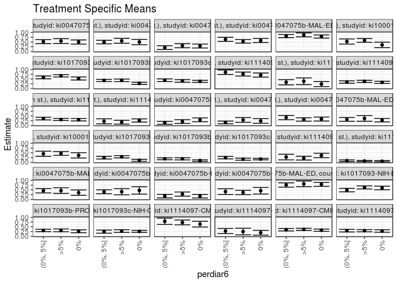

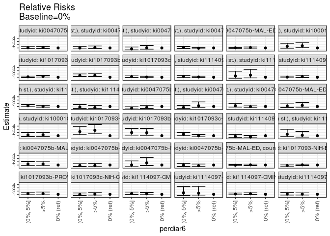

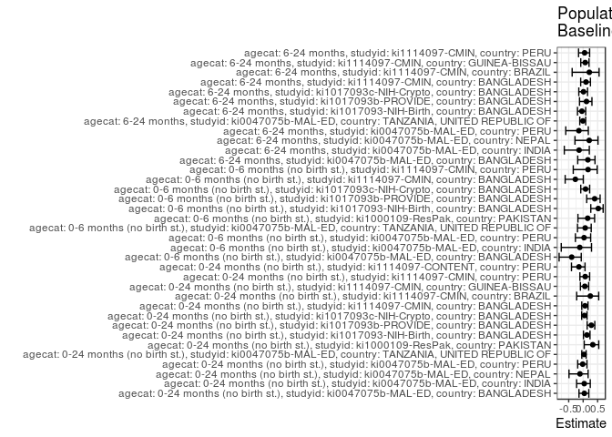

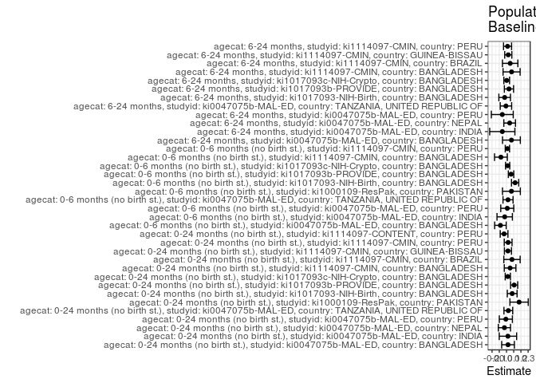

## Results Table

### Parameter: TSM

| agecat | studyid | country | intervention_level | baseline_level | estimate | ci_lower | ci_upper |
| --- | --- | --- | --- | --- | --- | --- | --- |
| 0-24 months (no birth st.) | ki0047075b-MAL-ED | BANGLADESH | 0% | NA | 0.4992655 | 0.3900698 | 0.6084612 |
| 0-24 months (no birth st.) | ki0047075b-MAL-ED | BANGLADESH | (0%, 5%] | NA | 0.5202214 | 0.4163727 | 0.6240701 |
| 0-24 months (no birth st.) | ki0047075b-MAL-ED | BANGLADESH | >5% | NA | 0.5506347 | 0.4241081 | 0.6771613 |
| 0-24 months (no birth st.) | ki0047075b-MAL-ED | INDIA | 0% | NA | 0.4968432 | 0.3571575 | 0.6365289 |
| 0-24 months (no birth st.) | ki0047075b-MAL-ED | INDIA | (0%, 5%] | NA | 0.4962521 | 0.4024297 | 0.5900744 |
| 0-24 months (no birth st.) | ki0047075b-MAL-ED | INDIA | >5% | NA | 0.5611165 | 0.4331100 | 0.6891229 |
| 0-24 months (no birth st.) | ki0047075b-MAL-ED | NEPAL | 0% | NA | 0.2882241 | 0.1835937 | 0.3928545 |
| 0-24 months (no birth st.) | ki0047075b-MAL-ED | NEPAL | (0%, 5%] | NA | 0.2070361 | 0.1106861 | 0.3033860 |
| 0-24 months (no birth st.) | ki0047075b-MAL-ED | NEPAL | >5% | NA | 0.3060997 | 0.1977430 | 0.4144563 |
| 0-24 months (no birth st.) | ki0047075b-MAL-ED | PERU | 0% | NA | 0.5764979 | 0.4693583 | 0.6836375 |
| 0-24 months (no birth st.) | ki0047075b-MAL-ED | PERU | (0%, 5%] | NA | 0.6390353 | 0.5311262 | 0.7469445 |
| 0-24 months (no birth st.) | ki0047075b-MAL-ED | PERU | >5% | NA | 0.5355386 | 0.4399809 | 0.6310962 |
| 0-24 months (no birth st.) | ki0047075b-MAL-ED | TANZANIA, UNITED REPUBLIC OF | 0% | NA | 0.7872340 | 0.7043099 | 0.8701582 |
| 0-24 months (no birth st.) | ki0047075b-MAL-ED | TANZANIA, UNITED REPUBLIC OF | (0%, 5%] | NA | 0.8117647 | 0.7284737 | 0.8950557 |
| 0-24 months (no birth st.) | ki0047075b-MAL-ED | TANZANIA, UNITED REPUBLIC OF | >5% | NA | 0.8750000 | 0.7722762 | 0.9777238 |
| 0-24 months (no birth st.) | ki1000109-ResPak | PAKISTAN | 0% | NA | 0.3476499 | 0.2045606 | 0.4907391 |
| 0-24 months (no birth st.) | ki1000109-ResPak | PAKISTAN | (0%, 5%] | NA | 0.5274035 | 0.3928932 | 0.6619139 |
| 0-24 months (no birth st.) | ki1000109-ResPak | PAKISTAN | >5% | NA | 0.5834247 | 0.4855613 | 0.6812881 |
| 0-24 months (no birth st.) | ki1017093-NIH-Birth | BANGLADESH | 0% | NA | 0.5250875 | 0.4446227 | 0.6055523 |
| 0-24 months (no birth st.) | ki1017093-NIH-Birth | BANGLADESH | (0%, 5%] | NA | 0.5847617 | 0.5101447 | 0.6593788 |
| 0-24 months (no birth st.) | ki1017093-NIH-Birth | BANGLADESH | >5% | NA | 0.6652664 | 0.6047965 | 0.7257363 |
| 0-24 months (no birth st.) | ki1017093b-PROVIDE | BANGLADESH | 0% | NA | 0.2693408 | 0.2105088 | 0.3281727 |
| 0-24 months (no birth st.) | ki1017093b-PROVIDE | BANGLADESH | (0%, 5%] | NA | 0.4214670 | 0.3621475 | 0.4807865 |
| 0-24 months (no birth st.) | ki1017093b-PROVIDE | BANGLADESH | >5% | NA | 0.4272915 | 0.3599167 | 0.4946662 |
| 0-24 months (no birth st.) | ki1017093c-NIH-Crypto | BANGLADESH | 0% | NA | 0.3752115 | 0.3233165 | 0.4271065 |
| 0-24 months (no birth st.) | ki1017093c-NIH-Crypto | BANGLADESH | (0%, 5%] | NA | 0.4330785 | 0.3619800 | 0.5041770 |
| 0-24 months (no birth st.) | ki1017093c-NIH-Crypto | BANGLADESH | >5% | NA | 0.3957838 | 0.3281737 | 0.4633939 |
| 0-24 months (no birth st.) | ki1114097-CMIN | BANGLADESH | 0% | NA | 0.7058824 | 0.5972606 | 0.8145041 |
| 0-24 months (no birth st.) | ki1114097-CMIN | BANGLADESH | (0%, 5%] | NA | 0.8529412 | 0.7335396 | 0.9723428 |
| 0-24 months (no birth st.) | ki1114097-CMIN | BANGLADESH | >5% | NA | 0.7575758 | 0.6538770 | 0.8612745 |

[output cut: 78 more lines]

### Parameter: E(Y)

| agecat | studyid | country | intervention_level | baseline_level | estimate | ci_lower | ci_upper |
| --- | --- | --- | --- | --- | --- | --- | --- |
| 0-24 months (no birth st.) | ki0047075b-MAL-ED | BANGLADESH | NA | NA | 0.5207373 | 0.4541154 | 0.5873593 |
| 0-24 months (no birth st.) | ki0047075b-MAL-ED | INDIA | NA | NA | 0.5167464 | 0.4488350 | 0.5846578 |
| 0-24 months (no birth st.) | ki0047075b-MAL-ED | NEPAL | NA | NA | 0.2594340 | 0.2002911 | 0.3185768 |
| 0-24 months (no birth st.) | ki0047075b-MAL-ED | PERU | NA | NA | 0.5676692 | 0.5080232 | 0.6273151 |
| 0-24 months (no birth st.) | ki0047075b-MAL-ED | TANZANIA, UNITED REPUBLIC OF | NA | NA | 0.8127854 | 0.7610035 | 0.8645672 |
| 0-24 months (no birth st.) | ki1000109-ResPak | PAKISTAN | NA | NA | 0.5223881 | 0.4531624 | 0.5916138 |
| 0-24 months (no birth st.) | ki1017093-NIH-Birth | BANGLADESH | NA | NA | 0.6041667 | 0.5624147 | 0.6459187 |
| 0-24 months (no birth st.) | ki1017093b-PROVIDE | BANGLADESH | NA | NA | 0.3753943 | 0.3376725 | 0.4131162 |
| 0-24 months (no birth st.) | ki1017093c-NIH-Crypto | BANGLADESH | NA | NA | 0.3935681 | 0.3560687 | 0.4310676 |
| 0-24 months (no birth st.) | ki1114097-CMIN | BANGLADESH | NA | NA | 0.7559524 | 0.6908084 | 0.8210964 |
| 0-24 months (no birth st.) | ki1114097-CMIN | BRAZIL | NA | NA | 0.3070175 | 0.2219720 | 0.3920631 |
| 0-24 months (no birth st.) | ki1114097-CMIN | GUINEA-BISSAU | NA | NA | 0.3443038 | 0.3111501 | 0.3774575 |
| 0-24 months (no birth st.) | ki1114097-CMIN | PERU | NA | NA | 0.3229167 | 0.2875370 | 0.3582963 |
| 0-24 months (no birth st.) | ki1114097-CONTENT | PERU | NA | NA | 0.2284264 | 0.1696529 | 0.2871999 |
| 0-6 months (no birth st.) | ki0047075b-MAL-ED | BANGLADESH | NA | NA | 0.2119816 | 0.1574763 | 0.2664868 |
| 0-6 months (no birth st.) | ki0047075b-MAL-ED | INDIA | NA | NA | 0.2105263 | 0.1551227 | 0.2659300 |
| 0-6 months (no birth st.) | ki0047075b-MAL-ED | PERU | NA | NA | 0.3458647 | 0.2885967 | 0.4031327 |
| 0-6 months (no birth st.) | ki0047075b-MAL-ED | TANZANIA, UNITED REPUBLIC OF | NA | NA | 0.2968037 | 0.2361590 | 0.3574483 |
| 0-6 months (no birth st.) | ki1000109-ResPak | PAKISTAN | NA | NA | 0.4378109 | 0.3690538 | 0.5065681 |
| 0-6 months (no birth st.) | ki1017093-NIH-Birth | BANGLADESH | NA | NA | 0.2291667 | 0.1932828 | 0.2650505 |
| 0-6 months (no birth st.) | ki1017093b-PROVIDE | BANGLADESH | NA | NA | 0.1593060 | 0.1307970 | 0.1878149 |
| 0-6 months (no birth st.) | ki1017093c-NIH-Crypto | BANGLADESH | NA | NA | 0.1898928 | 0.1597870 | 0.2199986 |
| 0-6 months (no birth st.) | ki1114097-CMIN | BANGLADESH | NA | NA | 0.2857143 | 0.2171983 | 0.3542303 |
| 0-6 months (no birth st.) | ki1114097-CMIN | PERU | NA | NA | 0.0744681 | 0.0543935 | 0.0945427 |
| 6-24 months | ki0047075b-MAL-ED | BANGLADESH | NA | NA | 0.4213836 | 0.3443902 | 0.4983771 |
| 6-24 months | ki0047075b-MAL-ED | INDIA | NA | NA | 0.4129032 | 0.3351414 | 0.4906651 |
| 6-24 months | ki0047075b-MAL-ED | NEPAL | NA | NA | 0.2102564 | 0.1529155 | 0.2675974 |
| 6-24 months | ki0047075b-MAL-ED | PERU | NA | NA | 0.3959732 | 0.3171819 | 0.4747644 |
| 6-24 months | ki0047075b-MAL-ED | TANZANIA, UNITED REPUBLIC OF | NA | NA | 0.7793103 | 0.7115754 | 0.8470453 |
| 6-24 months | ki1017093-NIH-Birth | BANGLADESH | NA | NA | 0.5739130 | 0.5216565 | 0.6261696 |
| 6-24 months | ki1017093b-PROVIDE | BANGLADESH | NA | NA | 0.2997812 | 0.2577294 | 0.3418330 |
| 6-24 months | ki1017093c-NIH-Crypto | BANGLADESH | NA | NA | 0.2628458 | 0.2244546 | 0.3012371 |
| 6-24 months | ki1114097-CMIN | BANGLADESH | NA | NA | 0.7117117 | 0.6270636 | 0.7963598 |
| 6-24 months | ki1114097-CMIN | BRAZIL | NA | NA | 0.2403846 | 0.1578607 | 0.3229085 |
| 6-24 months | ki1114097-CMIN | GUINEA-BISSAU | NA | NA | 0.3467532 | 0.3131150 | 0.3803915 |
| 6-24 months | ki1114097-CMIN | PERU | NA | NA | 0.2940171 | 0.2570662 | 0.3309680 |

### Parameter: RR

| agecat | studyid | country | intervention_level | baseline_level | estimate | ci_lower | ci_upper |
| --- | --- | --- | --- | --- | --- | --- | --- |
| 0-24 months (no birth st.) | ki0047075b-MAL-ED | BANGLADESH | 0% | 0% | 1.0000000 | 1.0000000 | 1.0000000 |
| 0-24 months (no birth st.) | ki0047075b-MAL-ED | BANGLADESH | (0%, 5%] | 0% | 1.0419734 | 0.7827083 | 1.3871178 |
| 0-24 months (no birth st.) | ki0047075b-MAL-ED | BANGLADESH | >5% | 0% | 1.1028895 | 0.8098259 | 1.5020084 |
| 0-24 months (no birth st.) | ki0047075b-MAL-ED | INDIA | 0% | 0% | 1.0000000 | 1.0000000 | 1.0000000 |
| 0-24 months (no birth st.) | ki0047075b-MAL-ED | INDIA | (0%, 5%] | 0% | 0.9988101 | 0.7158875 | 1.3935452 |
| 0-24 months (no birth st.) | ki0047075b-MAL-ED | INDIA | >5% | 0% | 1.1293632 | 0.7904356 | 1.6136180 |
| 0-24 months (no birth st.) | ki0047075b-MAL-ED | NEPAL | 0% | 0% | 1.0000000 | 1.0000000 | 1.0000000 |
| 0-24 months (no birth st.) | ki0047075b-MAL-ED | NEPAL | (0%, 5%] | 0% | 0.7183162 | 0.3975275 | 1.2979687 |
| 0-24 months (no birth st.) | ki0047075b-MAL-ED | NEPAL | >5% | 0% | 1.0620197 | 0.6389917 | 1.7651024 |
| 0-24 months (no birth st.) | ki0047075b-MAL-ED | PERU | 0% | 0% | 1.0000000 | 1.0000000 | 1.0000000 |
| 0-24 months (no birth st.) | ki0047075b-MAL-ED | PERU | (0%, 5%] | 0% | 1.1084782 | 0.8613626 | 1.4264885 |
| 0-24 months (no birth st.) | ki0047075b-MAL-ED | PERU | >5% | 0% | 0.9289515 | 0.7190405 | 1.2001422 |
| 0-24 months (no birth st.) | ki0047075b-MAL-ED | TANZANIA, UNITED REPUBLIC OF | 0% | 0% | 1.0000000 | 1.0000000 | 1.0000000 |
| 0-24 months (no birth st.) | ki0047075b-MAL-ED | TANZANIA, UNITED REPUBLIC OF | (0%, 5%] | 0% | 1.0311606 | 0.8901510 | 1.1945076 |
| 0-24 months (no birth st.) | ki0047075b-MAL-ED | TANZANIA, UNITED REPUBLIC OF | >5% | 0% | 1.1114865 | 0.9493007 | 1.3013814 |
| 0-24 months (no birth st.) | ki1000109-ResPak | PAKISTAN | 0% | 0% | 1.0000000 | 1.0000000 | 1.0000000 |
| 0-24 months (no birth st.) | ki1000109-ResPak | PAKISTAN | (0%, 5%] | 0% | 1.5170537 | 0.9349909 | 2.4614698 |
| 0-24 months (no birth st.) | ki1000109-ResPak | PAKISTAN | >5% | 0% | 1.6781962 | 1.0763048 | 2.6166773 |
| 0-24 months (no birth st.) | ki1017093-NIH-Birth | BANGLADESH | 0% | 0% | 1.0000000 | 1.0000000 | 1.0000000 |
| 0-24 months (no birth st.) | ki1017093-NIH-Birth | BANGLADESH | (0%, 5%] | 0% | 1.1136463 | 0.9151521 | 1.3551934 |
| 0-24 months (no birth st.) | ki1017093-NIH-Birth | BANGLADESH | >5% | 0% | 1.2669630 | 1.0616887 | 1.5119266 |
| 0-24 months (no birth st.) | ki1017093b-PROVIDE | BANGLADESH | 0% | 0% | 1.0000000 | 1.0000000 | 1.0000000 |
| 0-24 months (no birth st.) | ki1017093b-PROVIDE | BANGLADESH | (0%, 5%] | 0% | 1.5648096 | 1.2155892 | 2.0143557 |
| 0-24 months (no birth st.) | ki1017093b-PROVIDE | BANGLADESH | >5% | 0% | 1.5864346 | 1.2180481 | 2.0662358 |
| 0-24 months (no birth st.) | ki1017093c-NIH-Crypto | BANGLADESH | 0% | 0% | 1.0000000 | 1.0000000 | 1.0000000 |
| 0-24 months (no birth st.) | ki1017093c-NIH-Crypto | BANGLADESH | (0%, 5%] | 0% | 1.1542250 | 0.9399769 | 1.4173065 |
| 0-24 months (no birth st.) | ki1017093c-NIH-Crypto | BANGLADESH | >5% | 0% | 1.0548286 | 0.8510193 | 1.3074479 |
| 0-24 months (no birth st.) | ki1114097-CMIN | BANGLADESH | 0% | 0% | 1.0000000 | 1.0000000 | 1.0000000 |
| 0-24 months (no birth st.) | ki1114097-CMIN | BANGLADESH | (0%, 5%] | 0% | 1.2083333 | 0.9813886 | 1.4877587 |
| 0-24 months (no birth st.) | ki1114097-CMIN | BANGLADESH | >5% | 0% | 1.0732323 | 0.8734742 | 1.3186739 |

[output cut: 78 more lines]

### Parameter: PAR

| agecat | studyid | country | intervention_level | baseline_level | estimate | ci_lower | ci_upper |
| --- | --- | --- | --- | --- | --- | --- | --- |
| 0-24 months (no birth st.) | ki0047075b-MAL-ED | BANGLADESH | 0% | NA | 0.0214718 | -0.0666946 | 0.1096383 |
| 0-24 months (no birth st.) | ki0047075b-MAL-ED | INDIA | 0% | NA | 0.0199032 | -0.1005909 | 0.1403972 |
| 0-24 months (no birth st.) | ki0047075b-MAL-ED | NEPAL | 0% | NA | -0.0287901 | -0.1132175 | 0.0556372 |
| 0-24 months (no birth st.) | ki0047075b-MAL-ED | PERU | 0% | NA | -0.0088287 | -0.0994360 | 0.0817786 |
| 0-24 months (no birth st.) | ki0047075b-MAL-ED | TANZANIA, UNITED REPUBLIC OF | 0% | NA | 0.0255513 | -0.0349031 | 0.0860057 |
| 0-24 months (no birth st.) | ki1000109-ResPak | PAKISTAN | 0% | NA | 0.1747382 | 0.0478095 | 0.3016668 |
| 0-24 months (no birth st.) | ki1017093-NIH-Birth | BANGLADESH | 0% | NA | 0.0790792 | 0.0113648 | 0.1467936 |
| 0-24 months (no birth st.) | ki1017093b-PROVIDE | BANGLADESH | 0% | NA | 0.1060536 | 0.0566006 | 0.1555065 |
| 0-24 months (no birth st.) | ki1017093c-NIH-Crypto | BANGLADESH | 0% | NA | 0.0183567 | -0.0178409 | 0.0545542 |
| 0-24 months (no birth st.) | ki1114097-CMIN | BANGLADESH | 0% | NA | 0.0500700 | -0.0304974 | 0.1306374 |
| 0-24 months (no birth st.) | ki1114097-CMIN | BRAZIL | 0% | NA | 0.0762483 | -0.0369029 | 0.1893995 |
| 0-24 months (no birth st.) | ki1114097-CMIN | GUINEA-BISSAU | 0% | NA | 0.0205737 | -0.0285363 | 0.0696837 |
| 0-24 months (no birth st.) | ki1114097-CMIN | PERU | 0% | NA | 0.0229405 | -0.0309696 | 0.0768505 |
| 0-24 months (no birth st.) | ki1114097-CONTENT | PERU | 0% | NA | -0.0332558 | -0.0866666 | 0.0201549 |
| 0-6 months (no birth st.) | ki0047075b-MAL-ED | BANGLADESH | 0% | NA | -0.0841382 | -0.1641503 | -0.0041261 |
| 0-6 months (no birth st.) | ki0047075b-MAL-ED | INDIA | 0% | NA | -0.0247316 | -0.1313188 | 0.0818557 |
| 0-6 months (no birth st.) | ki0047075b-MAL-ED | PERU | 0% | NA | 0.0109547 | -0.0792940 | 0.1012035 |
| 0-6 months (no birth st.) | ki0047075b-MAL-ED | TANZANIA, UNITED REPUBLIC OF | 0% | NA | 0.0212437 | -0.0483364 | 0.0908239 |
| 0-6 months (no birth st.) | ki1000109-ResPak | PAKISTAN | 0% | NA | 0.0682934 | -0.0553134 | 0.1919001 |
| 0-6 months (no birth st.) | ki1017093-NIH-Birth | BANGLADESH | 0% | NA | 0.1200127 | 0.0698131 | 0.1702124 |
| 0-6 months (no birth st.) | ki1017093b-PROVIDE | BANGLADESH | 0% | NA | 0.0634285 | 0.0258894 | 0.1009676 |
| 0-6 months (no birth st.) | ki1017093c-NIH-Crypto | BANGLADESH | 0% | NA | 0.0159987 | -0.0130989 | 0.0450964 |
| 0-6 months (no birth st.) | ki1114097-CMIN | BANGLADESH | 0% | NA | -0.0770685 | -0.1657378 | 0.0116009 |
| 0-6 months (no birth st.) | ki1114097-CMIN | PERU | 0% | NA | 0.0125956 | -0.0172466 | 0.0424379 |
| 6-24 months | ki0047075b-MAL-ED | BANGLADESH | 0% | NA | 0.0685377 | -0.0548156 | 0.1918911 |
| 6-24 months | ki0047075b-MAL-ED | INDIA | 0% | NA | -0.0578579 | -0.2326476 | 0.1169317 |
| 6-24 months | ki0047075b-MAL-ED | NEPAL | 0% | NA | 0.0440574 | -0.0366363 | 0.1247511 |
| 6-24 months | ki0047075b-MAL-ED | PERU | 0% | NA | -0.0581599 | -0.2097327 | 0.0934130 |
| 6-24 months | ki0047075b-MAL-ED | TANZANIA, UNITED REPUBLIC OF | 0% | NA | -0.0075749 | -0.0867885 | 0.0716387 |
| 6-24 months | ki1017093-NIH-Birth | BANGLADESH | 0% | NA | -0.0252724 | -0.1058059 | 0.0552610 |
| 6-24 months | ki1017093b-PROVIDE | BANGLADESH | 0% | NA | 0.0344974 | -0.0292920 | 0.0982868 |
| 6-24 months | ki1017093c-NIH-Crypto | BANGLADESH | 0% | NA | 0.0031718 | -0.0363308 | 0.0426744 |
| 6-24 months | ki1114097-CMIN | BANGLADESH | 0% | NA | 0.0706861 | -0.0474877 | 0.1888598 |
| 6-24 months | ki1114097-CMIN | BRAZIL | 0% | NA | 0.0511954 | -0.0558040 | 0.1581948 |
| 6-24 months | ki1114097-CMIN | GUINEA-BISSAU | 0% | NA | 0.0248756 | -0.0244430 | 0.0741943 |
| 6-24 months | ki1114097-CMIN | PERU | 0% | NA | 0.0150827 | -0.0406485 | 0.0708139 |

### Parameter: PAF

| agecat | studyid | country | intervention_level | baseline_level | estimate | ci_lower | ci_upper |
| --- | --- | --- | --- | --- | --- | --- | --- |
| 0-24 months (no birth st.) | ki0047075b-MAL-ED | BANGLADESH | 0% | NA | 0.0412335 | -0.1438907 | 0.1963977 |
| 0-24 months (no birth st.) | ki0047075b-MAL-ED | INDIA | 0% | NA | 0.0385163 | -0.2255888 | 0.2457088 |
| 0-24 months (no birth st.) | ki0047075b-MAL-ED | NEPAL | 0% | NA | -0.1109729 | -0.4893062 | 0.1712512 |
| 0-24 months (no birth st.) | ki0047075b-MAL-ED | PERU | 0% | NA | -0.0155526 | -0.1884531 | 0.1321938 |
| 0-24 months (no birth st.) | ki0047075b-MAL-ED | TANZANIA, UNITED REPUBLIC OF | 0% | NA | 0.0314368 | -0.0460885 | 0.1032166 |
| 0-24 months (no birth st.) | ki1000109-ResPak | PAKISTAN | 0% | NA | 0.3344988 | 0.0369842 | 0.5400991 |
| 0-24 months (no birth st.) | ki1017093-NIH-Birth | BANGLADESH | 0% | NA | 0.1308897 | 0.0105835 | 0.2365675 |
| 0-24 months (no birth st.) | ki1017093b-PROVIDE | BANGLADESH | 0% | NA | 0.2825124 | 0.1379560 | 0.4028282 |
| 0-24 months (no birth st.) | ki1017093c-NIH-Crypto | BANGLADESH | 0% | NA | 0.0466416 | -0.0499897 | 0.1343799 |
| 0-24 months (no birth st.) | ki1114097-CMIN | BANGLADESH | 0% | NA | 0.0662344 | -0.0474806 | 0.1676044 |
| 0-24 months (no birth st.) | ki1114097-CMIN | BRAZIL | 0% | NA | 0.2483516 | -0.2238161 | 0.5383495 |
| 0-24 months (no birth st.) | ki1114097-CMIN | GUINEA-BISSAU | 0% | NA | 0.0597544 | -0.0942372 | 0.1920748 |
| 0-24 months (no birth st.) | ki1114097-CMIN | PERU | 0% | NA | 0.0710414 | -0.1119026 | 0.2238853 |
| 0-24 months (no birth st.) | ki1114097-CONTENT | PERU | 0% | NA | -0.1455867 | -0.4037931 | 0.0651266 |
| 0-6 months (no birth st.) | ki0047075b-MAL-ED | BANGLADESH | 0% | NA | -0.3969129 | -0.8305182 | -0.0660182 |
| 0-6 months (no birth st.) | ki0047075b-MAL-ED | INDIA | 0% | NA | -0.1174749 | -0.7571556 | 0.2893344 |
| 0-6 months (no birth st.) | ki0047075b-MAL-ED | PERU | 0% | NA | 0.0316734 | -0.2676129 | 0.2602975 |
| 0-6 months (no birth st.) | ki0047075b-MAL-ED | TANZANIA, UNITED REPUBLIC OF | 0% | NA | 0.0715751 | -0.1949120 | 0.2786307 |
| 0-6 months (no birth st.) | ki1000109-ResPak | PAKISTAN | 0% | NA | 0.1559883 | -0.1798168 | 0.3962149 |
| 0-6 months (no birth st.) | ki1017093-NIH-Birth | BANGLADESH | 0% | NA | 0.5236919 | 0.2643833 | 0.6915930 |
| 0-6 months (no birth st.) | ki1017093b-PROVIDE | BANGLADESH | 0% | NA | 0.3981550 | 0.1226244 | 0.5871582 |
| 0-6 months (no birth st.) | ki1017093c-NIH-Crypto | BANGLADESH | 0% | NA | 0.0842515 | -0.0822100 | 0.2251085 |
| 0-6 months (no birth st.) | ki1114097-CMIN | BANGLADESH | 0% | NA | -0.2697396 | -0.6219312 | 0.0059759 |
| 0-6 months (no birth st.) | ki1114097-CMIN | PERU | 0% | NA | 0.1691412 | -0.3424134 | 0.4857573 |
| 6-24 months | ki0047075b-MAL-ED | BANGLADESH | 0% | NA | 0.1626493 | -0.1874003 | 0.4095030 |
| 6-24 months | ki0047075b-MAL-ED | INDIA | 0% | NA | -0.1401247 | -0.6518529 | 0.2130750 |
| 6-24 months | ki0047075b-MAL-ED | NEPAL | 0% | NA | 0.2095412 | -0.2834021 | 0.5131494 |
| 6-24 months | ki0047075b-MAL-ED | PERU | 0% | NA | -0.1468783 | -0.6010529 | 0.1784594 |
| 6-24 months | ki0047075b-MAL-ED | TANZANIA, UNITED REPUBLIC OF | 0% | NA | -0.0097200 | -0.1166819 | 0.0869965 |
| 6-24 months | ki1017093-NIH-Birth | BANGLADESH | 0% | NA | -0.0440353 | -0.1944562 | 0.0874427 |
| 6-24 months | ki1017093b-PROVIDE | BANGLADESH | 0% | NA | 0.1150752 | -0.1253736 | 0.3041494 |
| 6-24 months | ki1017093c-NIH-Crypto | BANGLADESH | 0% | NA | 0.0120671 | -0.1502662 | 0.1514909 |
| 6-24 months | ki1114097-CMIN | BANGLADESH | 0% | NA | 0.0993184 | -0.0847491 | 0.2521521 |
| 6-24 months | ki1114097-CMIN | BRAZIL | 0% | NA | 0.2129730 | -0.3802068 | 0.5512183 |
| 6-24 months | ki1114097-CMIN | GUINEA-BISSAU | 0% | NA | 0.0717387 | -0.0819748 | 0.2036145 |
| 6-24 months | ki1114097-CMIN | PERU | 0% | NA | 0.0512987 | -0.1585124 | 0.2231122 |